# Le pouvoir d’achat des ouvriers anglais du 16eme au 19eme siecle

Stephane Kui & Kevin Imbert

13 septembre 2018

## Question 1

Reproduction du graphe de Playfair à partir des donnees numeriques. Les donnees utilisees se trouvent dans le fichier “jeuB.csv” (situe dans le meme repertoire que ce fichier).

On commence tout d’abord par 2 graphes separant le prix du ble a l’annee et le salaire hebdomaire a l’annee.

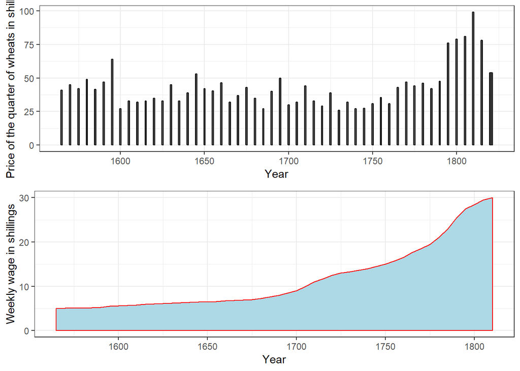

```r
line1 <- ggplot(data = jeuB, aes(x=Year, y=Wheat)) + geom_bar(colour="black", stat="identity") + labs (x="Year", y="Price of the quarter of wheats in shillings") + theme_bw()

line2 <- ggplot(jeuB, aes(x=Year, y=Wages))+ geom_area(color="red", fill="lightblue") + labs (x="Year", y="Weekly wage in shillings") + theme_bw()

grid.arrange(line1, line2)
```

On fusionne maintenant les 2 graphiques precedents en un seul :

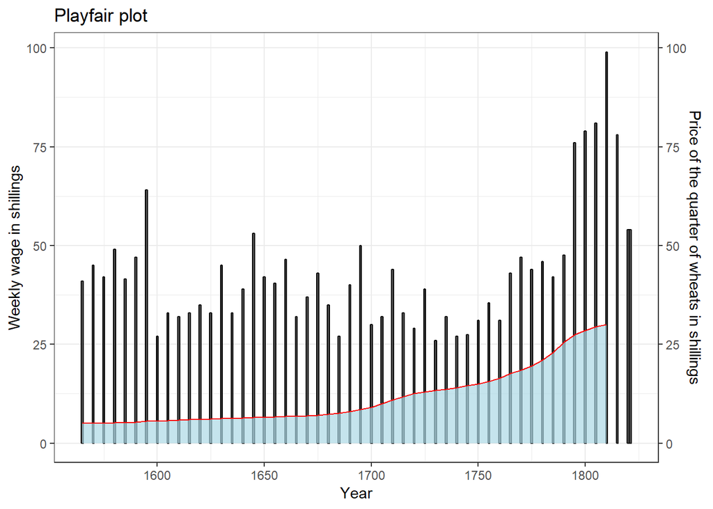

```r
ggplot(jeuB) + geom_bar(aes(x=Year, y=Wheat), stat = "identity", colour="black") + geom_area(aes(x=Year, y=Wages), fill="lightblue", alpha=0.7) + geom_line(aes(x=Year, y=Wages), color="red") + ggtitle("Playfair plot") + labs(x="Year", y= "Weekly wage in shillings") + scale_y_continuous(sec.axis = sec_axis(~.+0, name = "Price of the quarter of wheats in shillings"), position = "left") + theme_bw()
```

## Question 2

Amelioration de la presentation des donnees. On remplace l’unite “shillings par quart de boisseau de ble” par “shillings par kg de ble” et “shillings par semaine” par “shillings par an” (on ne prendra pas en compte ici les annees bissextiles).

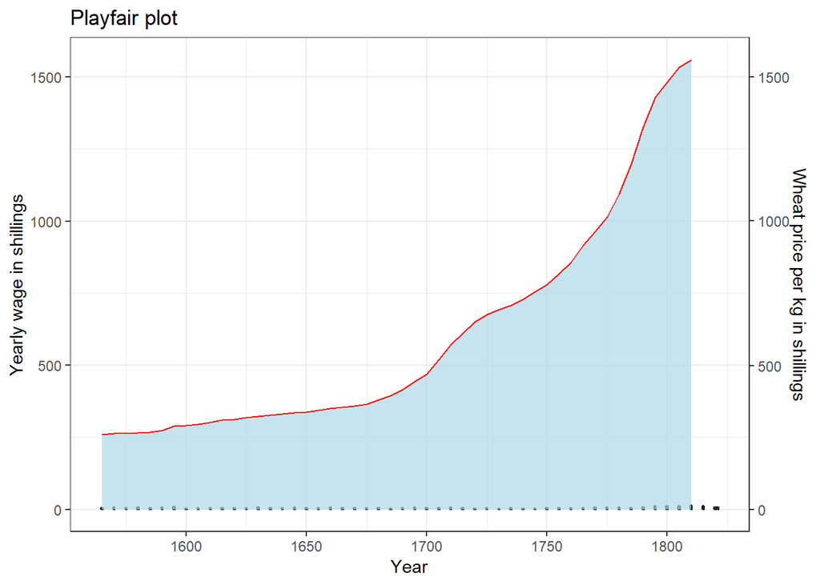

```r
ggplot(jeuB) + geom_bar(aes(x=Year, y=Wheat/6.8), stat = "identity", colour="black") + labs(x="Year", y= "Yearly wage in shillings") + geom_area(aes(x=Year, y=Wages*52), fill="lightblue", alpha=0.7) + geom_line(aes(x=Year, y=Wages*52), color="red") + ggtitle("Playfair plot") + scale_y_continuous(sec.axis = sec_axis(~.+0, name = "Wheat price per kg in shillings"), position = "left") + theme_bw()
```

Sous cette forme, le graphe est peu pertinent : on n’observe pas la relation entre les 2 unites utilisees et l’evolution du prix du ble est invisible.

Par consequent, nous modifions le graphe de façon a obtenir une echelle plus pertinente pour le prix du ble.

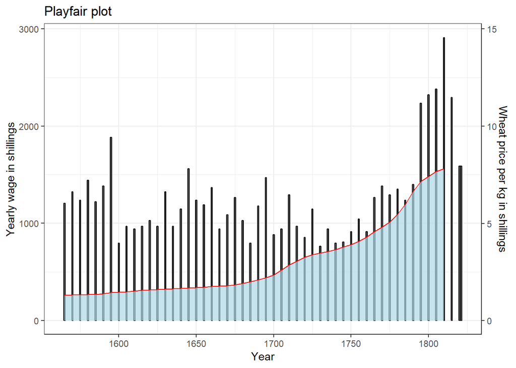

```r
ggplot(jeuB) + geom_bar(aes(x=Year, y=(Wheat/6.8)*200), stat = "identity", colour="black") + labs(x="Year", y= "Yearly wage in shillings") + geom_area(aes(x=Year, y=Wages*52), fill="lightblue", alpha=0.7) + geom_line(aes(x=Year, y=Wages*52), color="red") + ggtitle("Playfair plot") + scale_y_continuous(sec.axis = sec_axis(~./200, name = "Wheat price per kg in shillings"), position = "left") + theme_bw()
```

## Question 3

On va effectuer ici une représentation graphique du pouvoir d’achat des ouvriers au cours du temps.

Dans un premier temps, on définie le pouvoir d’achat comme la quantité de blé qu’un ouvrier peut acheter avec son salaire hebdomadaire.

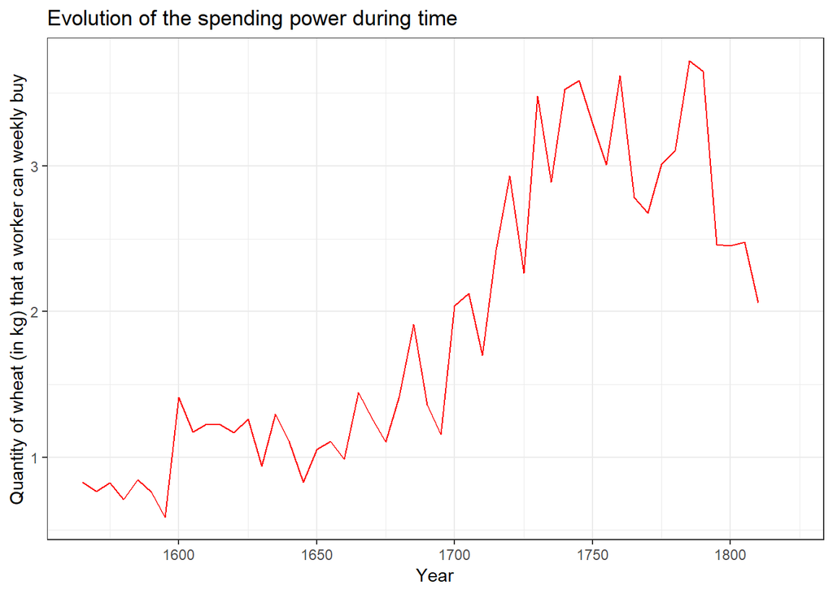

```r
ggplot(data = jeuB, aes(x=Year, y=Wages/(Wheat/6.8))) + geom_line(color="red") + labs (x="Year", y="Quantity of wheat (in kg) that a worker can weekly buy") + ggtitle("Evolution of the spending power during time") + theme_bw()
```

Sur ce graphique, on observe que le pouvoir d’achat des ouvriers augmentent au fur et à mesure du temp, jusqu’aux années 1730 environ où il commence à stagner, puis à diminuer vers les années 1780 environ. Cependant, même avec cette diminution, le pouvoir d’achat reste significativement plus élevé que les années précédents 1700.

On observe ensuite l’évolution du prix du blé en fonction des salaires (annuels).

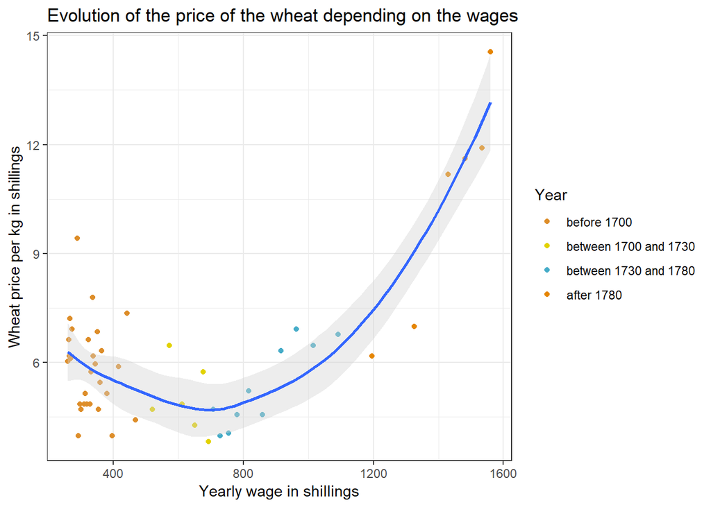

```r
ggplot(data = jeuB, aes(x=Wages*52, y=Wheat/6.8)) + geom_point(aes(color = cut(Year, c(-Inf, 1700, 1730, 1780, Inf)))) + scale_color_manual(name = "Year", values=wes_palette(n=4, name="FantasticFox1"), labels = c("before 1700", "between 1700 and 1730", "between 1730 and 1780", "after 1780")) + geom_smooth(fill="lightgrey") + labs (x="Yearly wage in shillings", y="Wheat price per kg in shillings") + ggtitle("Evolution of the price of the wheat depending on the wages") + theme_bw()
```

Selon les données, le salaire des ouvriers augmente au fur et à mesure du temps sans un moment d’exception. Dans le graphique ci-dessous, nous avons remplacé, par conséquent, l’axe du temps par celui du salaire annuel.

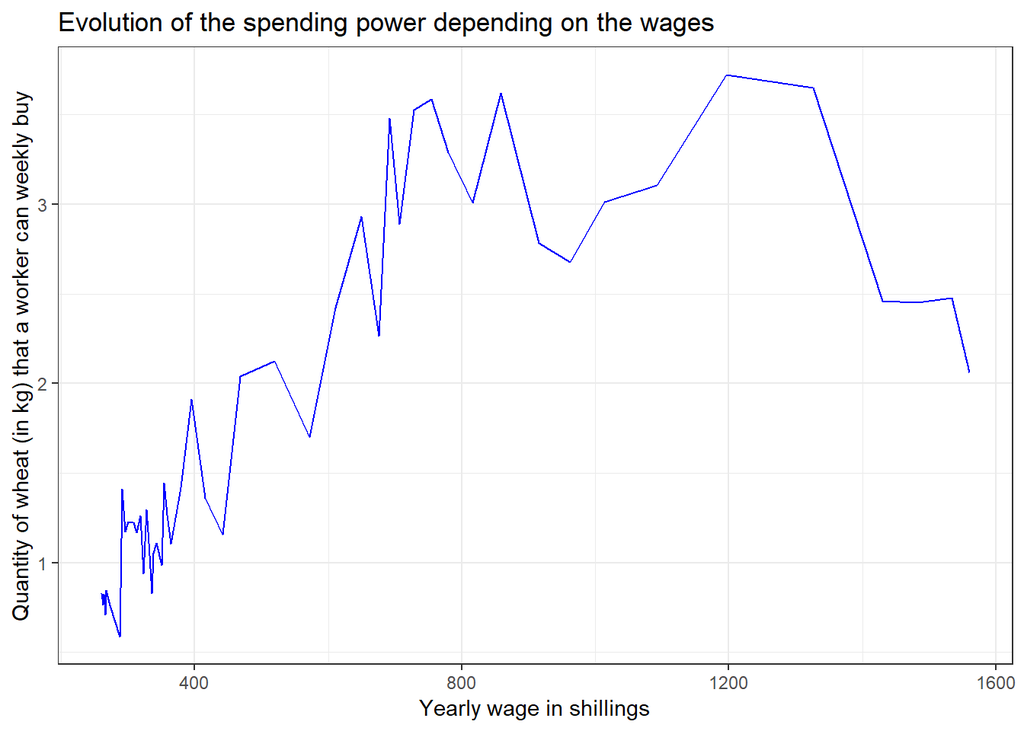

```r
ggplot(data = jeuB, aes(x=Wages*52, y=Wages/(Wheat/6.8))) + geom_line(color="blue") + labs (x="Yearly wage in shillings", y="Quantity of wheat (in kg) that a worker can weekly buy") + ggtitle("Evolution of the spending power depending on the wages") + theme_bw()
```

On retrouve ici une courbe affichant une évolution du pouvoir d’achat des ouvriers dans la même idée que le premier graphique. Cependant, l’augmentation significatif du pouvoir d’achat est ici moins évident.

Si nous souhaitons montrer que le pouvoir d’achats des ouvriers augmente au fur et à mesure du temps, nous trouvons donc que la première courbe est la plus pertinente parmi ces graphiques.